## Psuedocode lab

In this lab your goal is to write two functions from Pseudocode. As usual your are two save your file in an R script with your name and lab number.

### Newton’s Method

Newton’s method is a classical algorithm for finding a minimum of a function, for details see [Wiki](https://en.wikipedia.org/wiki/Newton%27s_method_in_optimization). Here is the pseudocode that describes the function you are supposed to impliment.

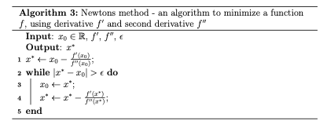

You are supposed implement the algorithm above in a function `newton(x0, df, ddf, epsilon = 1e-4)` that returns the value $x^*$ which hopefully is a minimum of $f(x)$. A good test if your function works is if it can find the minimum of the function:
$$(2-x)^2 + x^4$$
starting at $x_0 = 0$.

### Sampling from Gamma

In this exercise you are supoosed to write a function that generate a sample form a Gamma distrbution with shape parameter $\alpha$ and scale parameter $1$, i.e. $X \sim \Gamma(\alpha,1)$ when $0 <\alpha \leq 1$. Below is the pseudocode for an [accept-reject algorthim](https://en.wikipedia.org/wiki/Rejection_sampling) using only uniform random number between zero and one to generate the Gamma random variable:

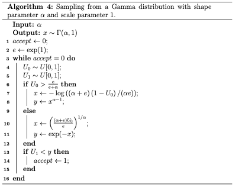

You are supposed write the function `sample.gamma(alpha)` that generates a sample of $\Gamma(\alpha,1)$. To check if your’e algorithm is correct a good tip is to generate lots of samples from the algorithm and check if the average value is equal to the expected value:

```
alpha =
EX    =

number.of.samples <- 1000
x <- rep(0, number.of.samples)
for(i in 1:number.of.samples){
  x[i] <- sample.gamma(alpha)
}
cat('mean(x)- truth = ', round(mean(x)-EX,2),'\n')
```

To find what EX should be look in [wiki](https://en.wikipedia.org/wiki/Gamma_distribution).

### testthat

When writing more advanced programs and packages it is fundamental to test that your function does what it supposed to do. a very useful package for this is `testthat`. To this lab you will get a file `test_lab7.R` that uses test that and has incorporate the to test described above. If you fill in the `source("")` on line 3 and `EX` on line 17, you can use this file to ensure that your functions does what they supposed todo. You can read more about testing in R at https://r-pkgs.org/tests.html To clarify this is only a helper file for you you should *not* send it in.